# Data Analyst Job Postings: A Brief Report

Tamayi Mlanda

May 24, 2026

## Introduction

This report explores a sample of Data Analyst job postings, focusing on how **minimum years of experience** and **required data languages** relate to the **median salary estimate** advertised in each posting.

The dataset contains 400 postings in total, of which 400 have a usable salary estimate, 309 have a parseable minimum-experience value, and 400 are tagged with a data-language category. Because experience and language requirements are extracted from free-text job descriptions, missing or noisy values are expected.

## Experience vs. Salary

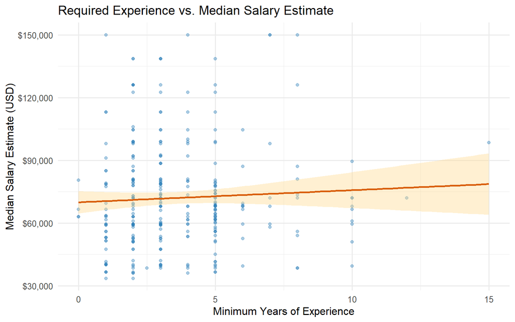

**Interpretation.** The scatter plot suggests a modest positive association between the minimum years of experience a posting requires and its median salary estimate: postings asking for more experience tend, on average, to advertise higher pay. The relationship is far from tight — there is wide salary variation at every experience level, reflecting differences in industry, location, company size, and seniority that this single variable does not capture.

## Salary by Data Language

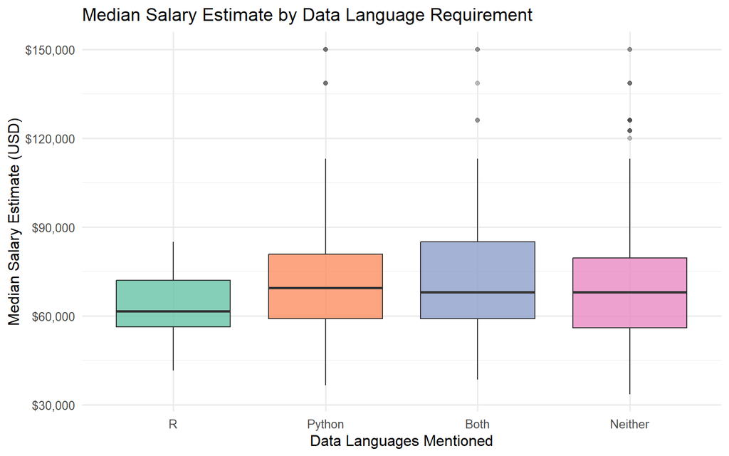

Salary summary by data-language requirement

| Data Languages | Postings | Median Salary | Mean Salary |
| --- | --- | --- | --- |
| R | 15 | $61,500 | $64,533.33 |
| Python | 63 | $69,500 | $75,603.17 |
| Both | 67 | $68,000 | $75,014.93 |
| Neither | 255 | $68,000 | $70,433.33 |

## Personal Reflection

- **LLMs Make Data Analysis Accessible:** Given the LLM, we were able to produce to a polished report with minimal coding and data manipulation. This opens up opportunities for people without advanced programming skills to be able to quickly produce summary reports.
- **LLMs Speed Up Data Analysis Tasks:** By relying on the LLM to analyse the text data of the Job Descriptions (natural language), we were able to quickly extract data and generate insights from the job descriptions. Previously, such a task would have had to be done manually, and that would have been time consuming because we would have to read through each job description.
- **LLM Risks:**
  - **Implicit Trust in the LLM, it might not always get it right:** The LLM is not perfect, and it can make mistakes in data extraction and analysis. It is important to verify the results produced by the LLM and to be aware of its limitations. For example, the LLM may have difficulty accurately extracting data from unstructured text, and it may not be able to capture all the nuances of the job descriptions. In this case, we did not verify whether it had extracted all the data correctly, we trusted it.
  - **The LLM is a black box, and inexperienced data analysts might not be able** **to interrogate the outputs of an LLM:** Because the LLM is a black box, it can be difficult to understand how it arrived at its conclusions. This can make it challenging to identify and correct any errors in the analysis. It also makes it difficult to understand the reasoning behind the insights generated by the LLM, which can be a problem when trying to communicate those insights to others.
- **My Prompts:**

  Extract Programming Language Requirement:

  ```
  =MYGPT(CONCATENATE("Analyze the Job Description and return ONLY one of these four specific strings based on the data programming language requirements in the job description: R, Python, Both, or Neither. Here's the job description: ", C2), GEN_AI_MODEL_NAME, OPENROUTER_API_KEY)
  ```